# Biostat 203B Homework 4

Due Mar 24 @ 11:59PM

Author

Jiaxin Cheng // 905946268

Load database libraries and the tidyverse frontend:

```r
suppressPackageStartupMessages(library(tidyverse))
suppressPackageStartupMessages(library(tidymodels))
suppressPackageStartupMessages(library(lubridate))
```

## 1 Predicting 30-day mortality

Using the ICU cohort `icu_cohort.rds` you built in Homework 3, develop at least three analytic approaches for predicting the 30-day mortality of patients admitted to ICU using demographic information (gender, age, marital status, ethnicity), first lab measurements during ICU stay, and first vital measurements during ICU stay. For example, you can use (1) logistic regression with elastic net (lasso + ridge) penalty (e.g., glmnet or keras package), (2) random forest, (3) boosting, and (4) support vector machines, or (5) MLP neural network (keras package)

1. Partition data into 50% training set and 50% test set. Stratify partitioning according the 30-day mortality status.

```r
library(GGally)
library(gtsummary)
library(tidyverse)
library(tidymodels)

icu_cohort <- read_rds("../HW3/mimiciv_shiny/icu_cohort.rds")
```

**solution**: Load data.

```r
selected_vars = c("gender", "age_at_admission", "marital_status",
              "ethnicity",
              "thirty_day_mort",
              "L50912",
              "L50971",
              "L50983",
              "L50902",
              "L50882",
              "L51221",
              "L51301",
              "L50931",
              "C220045",
              "C220181",
              "C220179",
              "C223761",
              "C220210")
icu_cohort_use <- icu_cohort[, selected_vars]
icu_cohort_use$thirty_day_mort <- as.factor(icu_cohort_use$thirty_day_mort)
icu_cohort_use <- na.omit(icu_cohort_use)
```

**solution**: Only keep the variables that we need. Since we have large observations, so I decide delete those incomplete row.

```r
set.seed(203)

data_split <- initial_split(
  icu_cohort_use,
  strata = "thirty_day_mort",
  prop = 0.5
  )
data_split
```

```
<Training/Testing/Total>
<22580/22580/45160>
```

```r
icu_cohort_other <- training(data_split)
dim(icu_cohort_other)
```

```
[1] 22580    18
```

```r
icu_cohort_test <- testing(data_split)
dim(icu_cohort_test)
```

```
[1] 22580    18
```

**solution**: Split dataset into train and test.

2. Train and tune the models using the training set.

(1). Random Forest Approach

```r
rf_recipe <-
  recipe(
    thirty_day_mort ~ .,
    data = icu_cohort_other
  ) %>%
  step_zv(all_numeric_predictors()) %>%
  prep(training = icu_cohort_other, retain = TRUE)
rf_recipe
```

```
Recipe

Inputs:

      role #variables
   outcome          1
 predictor         17

Training data contained 22580 data points and no missing data.

Operations:

Zero variance filter removed <none> [trained]
```

```r
rf_mod <-
  rand_forest(
    mode = "classification",
    mtry = tune(),
    trees = tune()
  ) %>%
  set_engine("ranger")
rf_mod
```

```
Random Forest Model Specification (classification)

Main Arguments:
  mtry = tune()
  trees = tune()

Computational engine: ranger
```

```r
rf_wf <- workflow() %>%
  add_recipe(rf_recipe) %>%
  add_model(rf_mod)
rf_wf
```

```
══ Workflow ════════════════════════════════════════════════════════════════════
Preprocessor: Recipe
Model: rand_forest()

── Preprocessor ────────────────────────────────────────────────────────────────
1 Recipe Step

• step_zv()

── Model ───────────────────────────────────────────────────────────────────────
Random Forest Model Specification (classification)

Main Arguments:
  mtry = tune()
  trees = tune()

Computational engine: ranger
```

```r
param_grid <- grid_regular(
  trees(range = c(100L, 500L)),
  mtry(range = c(2L, 8L)),
  levels = c(3, 5)
  )
param_grid
```

```
# A tibble: 15 × 2
   trees  mtry
   <int> <int>
 1   100     2
 2   300     2
 3   500     2
 4   100     3
 5   300     3
 6   500     3
 7   100     5
 8   300     5
 9   500     5
10   100     6
11   300     6
12   500     6
13   100     8
14   300     8
15   500     8
```

```r
set.seed(203)

folds <- vfold_cv(icu_cohort_other, v = 5)
folds
```

```
#  5-fold cross-validation
# A tibble: 5 × 2
  splits               id
  <list>               <chr>
1 <split [18064/4516]> Fold1
2 <split [18064/4516]> Fold2
3 <split [18064/4516]> Fold3
4 <split [18064/4516]> Fold4
5 <split [18064/4516]> Fold5
```

```r
rf_fit <- rf_wf %>%
  tune_grid(
    resamples = folds,
    grid = param_grid,
    metrics = metric_set(roc_auc, accuracy)
    )
rf_fit
```

```
# Tuning results
# 5-fold cross-validation
# A tibble: 5 × 4
  splits               id    .metrics          .notes
  <list>               <chr> <list>            <list>
1 <split [18064/4516]> Fold1 <tibble [30 × 6]> <tibble [0 × 3]>
2 <split [18064/4516]> Fold2 <tibble [30 × 6]> <tibble [0 × 3]>
3 <split [18064/4516]> Fold3 <tibble [30 × 6]> <tibble [0 × 3]>
4 <split [18064/4516]> Fold4 <tibble [30 × 6]> <tibble [0 × 3]>
5 <split [18064/4516]> Fold5 <tibble [30 × 6]> <tibble [0 × 3]>
```

```
# A tibble: 30 × 8
    mtry trees .metric  .estimator  mean     n std_err .config
   <int> <int> <chr>    <chr>      <dbl> <int>   <dbl> <chr>
 1     2   100 accuracy binary     0.917     5 0.00150 Preprocessor1_Model01
 2     2   100 roc_auc  binary     0.783     5 0.00541 Preprocessor1_Model01
 3     2   300 accuracy binary     0.917     5 0.00142 Preprocessor1_Model02
 4     2   300 roc_auc  binary     0.789     5 0.00473 Preprocessor1_Model02
 5     2   500 accuracy binary     0.917     5 0.00138 Preprocessor1_Model03
 6     2   500 roc_auc  binary     0.791     5 0.00513 Preprocessor1_Model03
 7     3   100 accuracy binary     0.918     5 0.00137 Preprocessor1_Model04
 8     3   100 roc_auc  binary     0.784     5 0.00616 Preprocessor1_Model04
 9     3   300 accuracy binary     0.917     5 0.00140 Preprocessor1_Model05
10     3   300 roc_auc  binary     0.787     5 0.00473 Preprocessor1_Model05
# … with 20 more rows
```

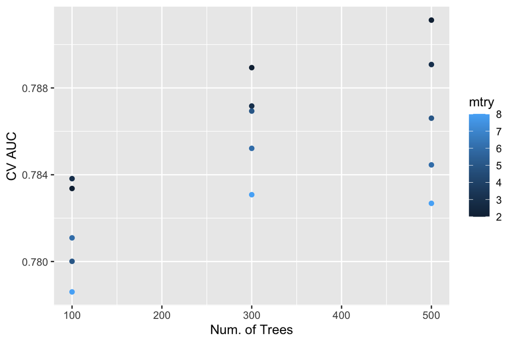

```r
rf_fit %>%
  collect_metrics() %>%
  print(width = Inf) %>%
  filter(.metric == "roc_auc") %>%
  ggplot(mapping = aes(x = trees, y = mean, color = mtry)) +
  geom_point() +
  # geom_line() +
  labs(x = "Num. of Trees", y = "CV AUC")
```

```r
rf_fit %>%
  show_best("roc_auc")
```

```
# A tibble: 5 × 8
   mtry trees .metric .estimator  mean     n std_err .config
  <int> <int> <chr>   <chr>      <dbl> <int>   <dbl> <chr>
1     2   500 roc_auc binary     0.791     5 0.00513 Preprocessor1_Model03
2     3   500 roc_auc binary     0.789     5 0.00485 Preprocessor1_Model06
3     2   300 roc_auc binary     0.789     5 0.00473 Preprocessor1_Model02
4     3   300 roc_auc binary     0.787     5 0.00473 Preprocessor1_Model05
5     5   300 roc_auc binary     0.787     5 0.00536 Preprocessor1_Model08
```

```r
best_rf <- rf_fit %>%
  select_best("roc_auc")
best_rf
```

```
# A tibble: 1 × 3
   mtry trees .config
  <int> <int> <chr>
1     2   500 Preprocessor1_Model03
```

```r
final_wf <- rf_wf %>%
  finalize_workflow(best_rf)
final_wf
```

```
══ Workflow ════════════════════════════════════════════════════════════════════
Preprocessor: Recipe
Model: rand_forest()

── Preprocessor ────────────────────────────────────────────────────────────────
1 Recipe Step

• step_zv()

── Model ───────────────────────────────────────────────────────────────────────
Random Forest Model Specification (classification)

Main Arguments:
  mtry = 2
  trees = 500

Computational engine: ranger
```

```r
final_fit <-
  final_wf %>%
  last_fit(data_split)
final_fit
```

```
# Resampling results
# Manual resampling
# A tibble: 1 × 6
  splits                id               .metrics .notes   .predict…¹ .workflow
  <list>                <chr>            <list>   <list>   <list>     <list>
1 <split [22580/22580]> train/test split <tibble> <tibble> <tibble>   <workflow>
# … with abbreviated variable name ¹.predictions
```

```r
final_fit %>%
  collect_metrics()
```

```
# A tibble: 2 × 4
  .metric  .estimator .estimate .config
  <chr>    <chr>          <dbl> <chr>
1 accuracy binary         0.922 Preprocessor1_Model1
2 roc_auc  binary         0.808 Preprocessor1_Model1
```

**Solution**: RF Accuracy is 0.9223649

(2).Boosting Approach

```r
gb_recipe <-
  recipe(
    thirty_day_mort ~ .,
    data = icu_cohort_other
  ) %>%
  step_dummy(all_nominal_predictors()) %>%
  step_zv(all_numeric_predictors()) %>%
  prep(training = icu_cohort_other, retain = TRUE)
gb_recipe
```

```
Recipe

Inputs:

      role #variables
   outcome          1
 predictor         17

Training data contained 22580 data points and no missing data.

Operations:

Dummy variables from gender, marital_status, ethnicity [trained]
Zero variance filter removed <none> [trained]
```

```r
gb_mod <-
  boost_tree(
    mode = "classification",
    trees = 1000,
    tree_depth = tune(),
    learn_rate = tune()
  ) %>%
  set_engine("xgboost")
gb_mod
```

```
Boosted Tree Model Specification (classification)

Main Arguments:
  trees = 1000
  tree_depth = tune()
  learn_rate = tune()

Computational engine: xgboost
```

```r
gb_wf <- workflow() %>%
  add_recipe(gb_recipe) %>%
  add_model(gb_mod)
gb_wf
```

```
══ Workflow ════════════════════════════════════════════════════════════════════
Preprocessor: Recipe
Model: boost_tree()

── Preprocessor ────────────────────────────────────────────────────────────────
2 Recipe Steps

• step_dummy()
• step_zv()

── Model ───────────────────────────────────────────────────────────────────────
Boosted Tree Model Specification (classification)

Main Arguments:
  trees = 1000
  tree_depth = tune()
  learn_rate = tune()

Computational engine: xgboost
```

```r
param_grid <- grid_regular(
  tree_depth(range = c(1L, 3L)),
  learn_rate(range = c(-5, 2), trans = log10_trans()),
  levels = c(3, 10)
  )
param_grid
```

```
# A tibble: 30 × 2
   tree_depth learn_rate
        <int>      <dbl>
 1          1  0.00001
 2          2  0.00001
 3          3  0.00001
 4          1  0.0000599
 5          2  0.0000599
 6          3  0.0000599
 7          1  0.000359
 8          2  0.000359
 9          3  0.000359
10          1  0.00215
# … with 20 more rows
```

```r
set.seed(203)

folds <- vfold_cv(icu_cohort_other, v = 5)
folds
```

```
#  5-fold cross-validation
# A tibble: 5 × 2
  splits               id
  <list>               <chr>
1 <split [18064/4516]> Fold1
2 <split [18064/4516]> Fold2
3 <split [18064/4516]> Fold3
4 <split [18064/4516]> Fold4
5 <split [18064/4516]> Fold5
```

```r
gb_fit <- gb_wf %>%
  tune_grid(
    resamples = folds,
    grid = param_grid,
    metrics = metric_set(roc_auc, accuracy)
    )
gb_fit
```

```
# Tuning results
# 5-fold cross-validation
# A tibble: 5 × 4
  splits               id    .metrics          .notes
  <list>               <chr> <list>            <list>
1 <split [18064/4516]> Fold1 <tibble [60 × 6]> <tibble [0 × 3]>
2 <split [18064/4516]> Fold2 <tibble [60 × 6]> <tibble [0 × 3]>
3 <split [18064/4516]> Fold3 <tibble [60 × 6]> <tibble [0 × 3]>
4 <split [18064/4516]> Fold4 <tibble [60 × 6]> <tibble [0 × 3]>
5 <split [18064/4516]> Fold5 <tibble [60 × 6]> <tibble [0 × 3]>
```

```
# A tibble: 60 × 8
   tree_depth learn_rate .metric  .estimator  mean     n std_err
        <int>      <dbl> <chr>    <chr>      <dbl> <int>   <dbl>
 1          1  0.00001   accuracy binary     0.916     5 0.00153
 2          1  0.00001   roc_auc  binary     0.617     5 0.00445
 3          2  0.00001   accuracy binary     0.916     5 0.00153
 4          2  0.00001   roc_auc  binary     0.671     5 0.00468
 5          3  0.00001   accuracy binary     0.915     5 0.00173
 6          3  0.00001   roc_auc  binary     0.697     5 0.00677
 7          1  0.0000599 accuracy binary     0.916     5 0.00153
 8          1  0.0000599 roc_auc  binary     0.619     5 0.00428
 9          2  0.0000599 accuracy binary     0.916     5 0.00153
10          2  0.0000599 roc_auc  binary     0.675     5 0.00387
   .config
   <chr>
 1 Preprocessor1_Model01
 2 Preprocessor1_Model01
 3 Preprocessor1_Model02
 4 Preprocessor1_Model02
 5 Preprocessor1_Model03
 6 Preprocessor1_Model03
 7 Preprocessor1_Model04
 8 Preprocessor1_Model04
 9 Preprocessor1_Model05
10 Preprocessor1_Model05
# … with 50 more rows
```

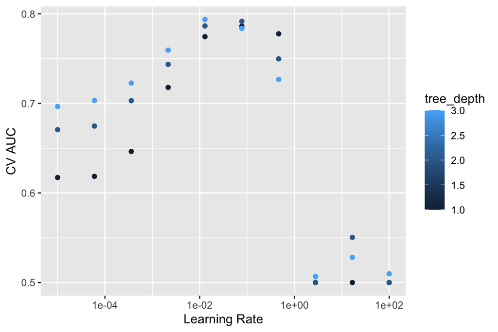

```r
gb_fit %>%
  collect_metrics() %>%
  print(width = Inf) %>%
  filter(.metric == "roc_auc") %>%
  ggplot(mapping = aes(x = learn_rate, y = mean, color = tree_depth)) +
  geom_point() +
  labs(x = "Learning Rate", y = "CV AUC") +
  scale_x_log10()
```

```r
gb_fit %>%
  show_best("roc_auc")
```

```
# A tibble: 5 × 8
  tree_depth learn_rate .metric .estimator  mean     n std_err .config
       <int>      <dbl> <chr>   <chr>      <dbl> <int>   <dbl> <chr>
1          3     0.0129 roc_auc binary     0.794     5 0.00493 Preprocessor1_Mo…
2          2     0.0774 roc_auc binary     0.792     5 0.00542 Preprocessor1_Mo…
3          2     0.0129 roc_auc binary     0.786     5 0.00434 Preprocessor1_Mo…
4          1     0.0774 roc_auc binary     0.786     5 0.00321 Preprocessor1_Mo…
5          3     0.0774 roc_auc binary     0.784     5 0.00470 Preprocessor1_Mo…
```

```r
best_gb <- gb_fit %>%
  select_best("roc_auc")
best_gb
```

```
# A tibble: 1 × 3
  tree_depth learn_rate .config
       <int>      <dbl> <chr>
1          3     0.0129 Preprocessor1_Model15
```

```r
final_wf <- gb_wf %>%
  finalize_workflow(best_gb)
final_wf
```

```
══ Workflow ════════════════════════════════════════════════════════════════════
Preprocessor: Recipe
Model: boost_tree()

── Preprocessor ────────────────────────────────────────────────────────────────
2 Recipe Steps

• step_dummy()
• step_zv()

── Model ───────────────────────────────────────────────────────────────────────
Boosted Tree Model Specification (classification)

Main Arguments:
  trees = 1000
  tree_depth = 3
  learn_rate = 0.0129154966501488

Computational engine: xgboost
```

```r
final_fit <-
  final_wf %>%
  last_fit(data_split)
final_fit
```

```
# Resampling results
# Manual resampling
# A tibble: 1 × 6
  splits                id               .metrics .notes   .predict…¹ .workflow
  <list>                <chr>            <list>   <list>   <list>     <list>
1 <split [22580/22580]> train/test split <tibble> <tibble> <tibble>   <workflow>
# … with abbreviated variable name ¹.predictions
```

```r
final_fit %>%
  collect_metrics()
```

```
# A tibble: 2 × 4
  .metric  .estimator .estimate .config
  <chr>    <chr>          <dbl> <chr>
1 accuracy binary         0.923 Preprocessor1_Model1
2 roc_auc  binary         0.810 Preprocessor1_Model1
```

**Solution**: Boosting accuracy is 0.9227192.

(3). Support Vector Machines

```r
svm_recipe <-
  recipe(
    thirty_day_mort ~ .,
    data = icu_cohort_other
  ) %>%
  step_dummy(all_nominal_predictors()) %>%
  step_zv(all_numeric_predictors()) %>%
  step_normalize(all_numeric_predictors()) %>%
  prep(training = icu_cohort_other, retain = TRUE)
svm_recipe
```

```
Recipe

Inputs:

      role #variables
   outcome          1
 predictor         17

Training data contained 22580 data points and no missing data.

Operations:

Dummy variables from gender, marital_status, ethnicity [trained]
Zero variance filter removed <none> [trained]
Centering and scaling for age_at_admission, L50912, L50971, L50983, L5090... [trained]
```

```r
svm_mod <-
  svm_rbf(
    mode = "classification",
    cost = tune(),
    rbf_sigma = tune()
  ) %>%
  set_engine("kernlab")
svm_mod
```

```
Radial Basis Function Support Vector Machine Model Specification (classification)

Main Arguments:
  cost = tune()
  rbf_sigma = tune()

Computational engine: kernlab
```

```r
svm_wf <- workflow() %>%
  add_recipe(svm_recipe) %>%
  add_model(svm_mod)
svm_wf
```

```
══ Workflow ════════════════════════════════════════════════════════════════════
Preprocessor: Recipe
Model: svm_rbf()

── Preprocessor ────────────────────────────────────────────────────────────────
3 Recipe Steps

• step_dummy()
• step_zv()
• step_normalize()

── Model ───────────────────────────────────────────────────────────────────────
Radial Basis Function Support Vector Machine Model Specification (classification)

Main Arguments:
  cost = tune()
  rbf_sigma = tune()

Computational engine: kernlab
```

```r
param_grid <- grid_regular(
  cost(range = c(-8, 5)),
  rbf_sigma(range = c(-5, -3)),
  levels = c(14, 5)
  )
param_grid
```

```
# A tibble: 70 × 2
      cost rbf_sigma
     <dbl>     <dbl>
 1 0.00391   0.00001
 2 0.00781   0.00001
 3 0.0156    0.00001
 4 0.0312    0.00001
 5 0.0625    0.00001
 6 0.125     0.00001
 7 0.25      0.00001
 8 0.5       0.00001
 9 1         0.00001
10 2         0.00001
# … with 60 more rows
```

```r
set.seed(203)

folds <- vfold_cv(icu_cohort_other, v = 5)
folds
```

```
#  5-fold cross-validation
# A tibble: 5 × 2
  splits               id
  <list>               <chr>
1 <split [18064/4516]> Fold1
2 <split [18064/4516]> Fold2
3 <split [18064/4516]> Fold3
4 <split [18064/4516]> Fold4
5 <split [18064/4516]> Fold5
```

```r
svm_fit <- svm_wf %>%
  tune_grid(
    resamples = folds,
    grid = param_grid,
    metrics = metric_set(roc_auc, accuracy)
    )
svm_fit
```

```
# Tuning results
# 5-fold cross-validation
# A tibble: 5 × 4
  splits               id    .metrics           .notes
  <list>               <chr> <list>             <list>
1 <split [18064/4516]> Fold1 <tibble [140 × 6]> <tibble [0 × 3]>
2 <split [18064/4516]> Fold2 <tibble [140 × 6]> <tibble [0 × 3]>
3 <split [18064/4516]> Fold3 <tibble [140 × 6]> <tibble [0 × 3]>
4 <split [18064/4516]> Fold4 <tibble [140 × 6]> <tibble [0 × 3]>
5 <split [18064/4516]> Fold5 <tibble [140 × 6]> <tibble [0 × 3]>
```

```
# A tibble: 140 × 8
      cost rbf_sigma .metric  .estimator  mean     n std_err
     <dbl>     <dbl> <chr>    <chr>      <dbl> <int>   <dbl>
 1 0.00391   0.00001 accuracy binary     0.916     5 0.00153
 2 0.00391   0.00001 roc_auc  binary     0.727     5 0.00803
 3 0.00781   0.00001 accuracy binary     0.916     5 0.00153
 4 0.00781   0.00001 roc_auc  binary     0.736     5 0.00597
 5 0.0156    0.00001 accuracy binary     0.916     5 0.00153
 6 0.0156    0.00001 roc_auc  binary     0.737     5 0.00554
 7 0.0312    0.00001 accuracy binary     0.916     5 0.00153
 8 0.0312    0.00001 roc_auc  binary     0.728     5 0.00829
 9 0.0625    0.00001 accuracy binary     0.916     5 0.00153
10 0.0625    0.00001 roc_auc  binary     0.694     5 0.0120
   .config
   <chr>
 1 Preprocessor1_Model01
 2 Preprocessor1_Model01
 3 Preprocessor1_Model02
 4 Preprocessor1_Model02
 5 Preprocessor1_Model03
 6 Preprocessor1_Model03
 7 Preprocessor1_Model04
 8 Preprocessor1_Model04
 9 Preprocessor1_Model05
10 Preprocessor1_Model05
# … with 130 more rows
```

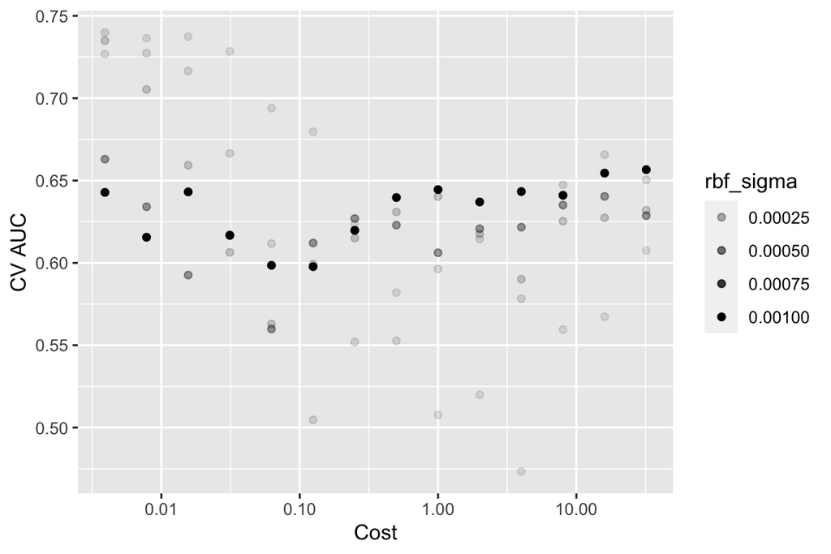

```r
svm_fit %>%
  collect_metrics() %>%
  print(width = Inf) %>%
  filter(.metric == "roc_auc") %>%
  ggplot(mapping = aes(x = cost, y = mean, alpha = rbf_sigma)) +
  geom_point() +
  labs(x = "Cost", y = "CV AUC") +
  scale_x_log10()
```

```r
svm_fit %>%
  show_best("roc_auc")
```

```
# A tibble: 5 × 8
     cost rbf_sigma .metric .estimator  mean     n std_err .config
    <dbl>     <dbl> <chr>   <chr>      <dbl> <int>   <dbl> <chr>
1 0.00391 0.0000316 roc_auc binary     0.740     5 0.00533 Preprocessor1_Model15
2 0.0156  0.00001   roc_auc binary     0.737     5 0.00554 Preprocessor1_Model03
3 0.00781 0.00001   roc_auc binary     0.736     5 0.00597 Preprocessor1_Model02
4 0.00391 0.0001    roc_auc binary     0.735     5 0.00746 Preprocessor1_Model29
5 0.0312  0.00001   roc_auc binary     0.728     5 0.00829 Preprocessor1_Model04
```

```r
best_svm <- svm_fit %>%
  select_best("roc_auc")
best_svm
```

```
# A tibble: 1 × 3
     cost rbf_sigma .config
    <dbl>     <dbl> <chr>
1 0.00391 0.0000316 Preprocessor1_Model15
```

```r
final_wf <- svm_wf %>%
  finalize_workflow(best_svm)
final_wf
```

```
══ Workflow ════════════════════════════════════════════════════════════════════
Preprocessor: Recipe
Model: svm_rbf()

── Preprocessor ────────────────────────────────────────────────────────────────
3 Recipe Steps

• step_dummy()
• step_zv()
• step_normalize()

── Model ───────────────────────────────────────────────────────────────────────
Radial Basis Function Support Vector Machine Model Specification (classification)

Main Arguments:
  cost = 0.00390625
  rbf_sigma = 3.16227766016838e-05

Computational engine: kernlab
```

```r
final_fit <-
  final_wf %>%
  last_fit(data_split)
final_fit
```

```
# Resampling results
# Manual resampling
# A tibble: 1 × 6
  splits                id               .metrics .notes   .predict…¹ .workflow
  <list>                <chr>            <list>   <list>   <list>     <list>
1 <split [22580/22580]> train/test split <tibble> <tibble> <tibble>   <workflow>
# … with abbreviated variable name ¹.predictions
```

```r
final_fit %>%
  collect_metrics()
```

```
# A tibble: 2 × 4
  .metric  .estimator .estimate .config
  <chr>    <chr>          <dbl> <chr>
1 accuracy binary         0.922 Preprocessor1_Model1
2 roc_auc  binary         0.756 Preprocessor1_Model1
```

**Solution**: Support Vector Machines approach accuracy is 0.9218778

3. Compare model classification performance on the test set. Report both the area under ROC curve and accuracy for each model.